# RNA-Seq Analysis in Early-Stage Lung Adenocarcinoma

November 03, 2023

# Introduction

Lung adenocarcinoma, a primary form of non-small cell lung cancer (NSCLC), presents significant challenges in treatment and prognosis. This study focuses on early-stage lung adenocarcinoma, particularly examining the transcriptome of tumor-adjacent lung tissue. The ability to predict recurrence post-surgery is crucial for patient management and therapy customization. This project aims to identify gene expression patterns and potential biomarkers in tumor-adjacent lung tissue that correlate with recurrence risk.

## Data Description

- **Accession Numbers:** PRJNA955664; GEO: GSE229705
- **Source:** The data, in the form of count matrices, were obtained from the NCBI Sequence Read Archive (SRA) and Gene Expression Omnibus (GEO).
- **Sample Details:**
  - Total Samples: 150 early-stage lung adenocarcinoma patients
  - Sample Types: Matched tumor and normal lung tissue samples

## **Pipeline Overview**

1. **Data Preprocessing:**
   - Normalization of read counts using the DESeq2 package.
   - Filtering of lowly expressed genes to enhance the robustness of subsequent analyses.
2. **Differential Expression Analysis:**
   - Utilization of DESeq2 for identifying differentially expressed genes (DEGs) across different conditions or comparisons.
   - Summarization of results with a focus on statistically significant DEGs.
3. **Data Visualization:**
   - Generation of heatmaps to visualize the expression patterns of DEGs.
   - Creation of volcano plots to graphically represent the relationship between fold-changes and statistical significance.
4. **Statistical Validation:**
   - Application of t-tests as a complementary approach to validate the DEGs identified by DESeq2.
   - Correction for multiple hypothesis testing where applicable.
5. **Clustering Analyses:**
   - Hierarchical clustering to identify patterns in gene expression and to group similar expression profiles.
   - K-means clustering to categorize genes into discrete clusters based on expression levels.
6. **Dimensionality Reduction and Feature Extraction:**
   - Performance of principal component analysis (PCA) to simplify the dataset and highlight the most variable genes.
   - Use of random forest classification to identify the most important features (genes) for group classification.
7. **Compilation of Results:**
   - Aggregation of top genes from PCA, random forest, and clustering analyses into a consolidated list for downstream analysis.
8. **Export of Results:**
   - Preparation of a final list of candidate genes for further analysis in separate, specialized notebooks.
   - Exportation of key findings and gene lists in CSV format for reproducibility and sharing.

# **Data Acquisition**

**Loading the Raw Counts**

```r
# Reading the raw counts file
counts_data <- read.csv(gzfile("Data/GSE229705_counts-raw.csv.gz"), header = TRUE)
```

**Loading metadata**

```r
# Reading the SDRF file
sra_run_table <- read.csv("Data/SraRunTable.txt", sep = ",", header = TRUE)

# selecting specific columns
metadata <- sra_run_table[, c("patient", "progression_type", "tissue", "recurrence")]

# Append tumor nor Normal to patient ID
metadata$PatientID <- ifelse(metadata$tissue == "Tumor",
                             paste0(metadata$patient, ".T"),
                             paste0(metadata$patient, ".N"))
```

Prepare and match column names

```r
# Extract patient IDs from the last column of metadata
patient_ids <- metadata[,ncol(metadata)]

# Remove the last column from metadata
metadata <- metadata[,-ncol(metadata)]

# Convert to a dataframe and set row names to patient IDs
metadata_df <- as.data.frame(metadata, stringsAsFactors = FALSE)
rownames(metadata_df) <- patient_ids
```

Filter out genes with low expression

```r
# Count the total number of genes before filtering
total_genes_before <- nrow(counts_data)
print(paste("Number of genes before filtering:", total_genes_before))
```

```
[1] "Number of genes before filtering: 60591"
```

```r
# Set the threshold for filtering
threshold <- round(0.3 * ncol(counts_data))  # 30% of the total number of samples

# Apply the filtering criteria, excluding the first column (gene identifiers)
keep <- rowSums(counts_data[, -1] > 1) >= threshold # threshold of 1
filtered_counts_data <- counts_data[keep,]

# Count the total number of genes after filtering
total_genes_after <- nrow(filtered_counts_data)
print(paste("Number of genes after filtering:", total_genes_after))
```

```
[1] "Number of genes after filtering: 29186"
```

Filter out mismatched names, reorder data

```r
# Get sample names from counts data, excluding the gene identifier column
sample_names_counts <- colnames(filtered_counts_data)[-1]

# Find common samples between counts data and metadata
common_samples <- intersect(sample_names_counts, rownames(metadata_df))

# Subsetting and reordering counts data to include gene identifiers and common samples
filtered_counts_data <- filtered_counts_data[, c(1, match(common_samples, sample_names_counts) + 1)]

# Reordering metadata to match the order of common samples
metadata_df <- metadata_df[match(common_samples, rownames(metadata_df)), ]

# Check alignment excluding the gene identifier column
all(rownames(metadata_df) == colnames(filtered_counts_data)[-1])
```

```
[1] TRUE
```

Create DESeq2 object

```r
# Replace 'Lung adjacent normal' with 'normal' in the tissue column
metadata_df$tissue <- gsub("Lung adjacent normal", "normal", metadata_df$tissue)

# convert the 'tissue' column to a factor
metadata_df$tissue <- as.factor(metadata_df$tissue)

# Set Gene IDs as Row Names
rownames(filtered_counts_data) <- filtered_counts_data[, 1]
# Then remove this column from the data
filtered_counts_data <- filtered_counts_data[, -1]

# create the DESeq2 object
dds <- DESeqDataSetFromMatrix(countData = filtered_counts_data, colData = metadata_df, design = ~ tissue)
```

# Differential Expression Analysis

Differential Expression Analysis

```r
dds <- DESeq(dds)
```

```
-- replacing outliers and refitting for 1332 genes
-- DESeq argument 'minReplicatesForReplace' = 7
-- original counts are preserved in counts(dds)
```

Extract results

```r
res <- results(dds, name = "tissue_Tumor_vs_normal")
```

#### Volcano Plot

```r
# Volcano plot
with(res, plot(log2FoldChange, -log10(pvalue), pch=20, main="Volcano plot", cex=0.5))

# Add blue points: significant genes
with(subset(res, padj < 0.01), points(log2FoldChange, -log10(pvalue), pch=20, col="blue", cex=0.5))
```

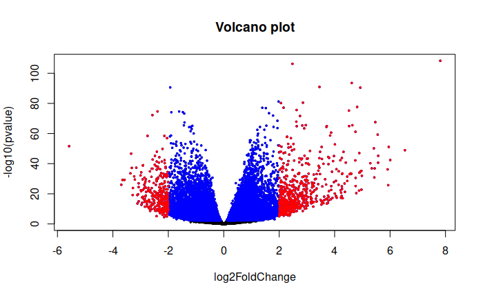

```r
# Add red points: significant  and large fold change (|log2FC| > 2)
with(subset(res, padj < 0.01 & abs(log2FoldChange) > 2), points(log2FoldChange, -log10(pvalue), pch=20, col="red", cex=0.5))
```

#### Heat-map

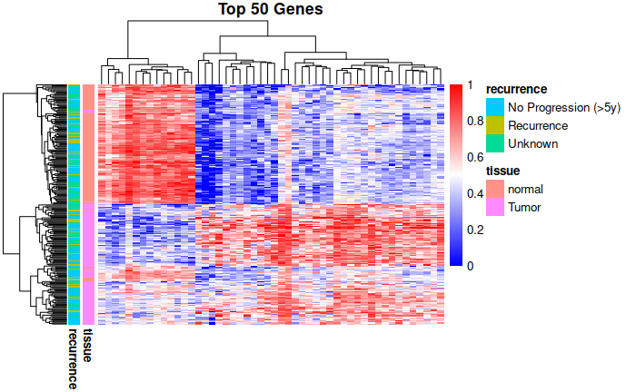

```r
# Extract the normalized counts for these genes
normalized_counts <- counts(dds, normalized=TRUE)

# Order the results by p-value
res_ordered <- res[order(res$pvalue), ]

# Select top N significant genes for the heatmap
top_n <- 50  # Adjust this number as needed
top_genes <- rownames(res_ordered)[1:top_n]

# Extract normalized counts for these genes
top_genes_data <- log2(normalized_counts[top_genes, ] + 1)

# Prepare sample annotations
sample_annotations <- metadata_df[, c("tissue", "recurrence")]
sample_annotations$recurrence[sample_annotations$recurrence == ""] <- "Unknown"  # Handle empty strings
sample_annotations$recurrence <- factor(sample_annotations$recurrence)
sample_annotations$tissue <- factor(sample_annotations$tissue)

# Ensure the order of samples in annotations matches the order in the data
sample_annotations_heatmap <- sample_annotations[colnames(top_genes_data), ]
rownames(sample_annotations_heatmap) <- colnames(top_genes_data)  # Adjust row names

# Apply min-max scaling to the data
scaled_data <- apply(top_genes_data, 1, function(x) (x - min(x)) / (max(x) - min(x)))

# Define color breaks
breaks <- seq(0, 1, length.out = 100)

# Draw the heatmap with row annotations
pheatmap(scaled_data, cluster_rows = TRUE, cluster_cols = TRUE,
         annotation_row = sample_annotations_heatmap,
         show_rownames = FALSE, show_colnames = FALSE,
         color = colorRampPalette(c("blue", "white", "red"))(100),
         breaks = breaks,
         main = "Top 50 Genes")  # Add this line for the title
```

```r
NA
NA
NA
```

# **T-test**

#### Perform t test

```r
# Extract expression data
expression_data <- counts(dds, normalized=TRUE)

# Initialize a vector to store p-values
p_values <- numeric(nrow(expression_data))
tissue_types <- metadata_df$tissue

# Perform t-tests for each gene
for (i in 1:nrow(expression_data)) {
    gene_data <- expression_data[i, ]
    if (length(unique(gene_data[tissue_types == "normal"])) > 1 &&
        length(unique(gene_data[tissue_types == "Tumor"])) > 1) {
        p_values[i] <- t.test(gene_data[tissue_types == "normal"],
                              gene_data[tissue_types == "Tumor"])$p.value
    } else {
        p_values[i] <- NA  # Assign NA if the test cannot be performed
    }
}

# Apply Benjamini-Hochberg correction
p_adjusted <- p.adjust(p_values, method = "BH")

# Define p-value threshold
pvalue_threshold <- 0.05

# Find significant genes before and after correction
significant_genes_before_correction <- rownames(expression_data)[!is.na(p_values) & p_values < pvalue_threshold]
significant_genes_after_correction <- rownames(expression_data)[!is.na(p_adjusted) & p_adjusted < pvalue_threshold]

# Outputting the results
cat("Total Number of Significant Genes Before Correction:", length(significant_genes_before_correction), "\n")
```

```
Total Number of Significant Genes Before Correction: 16367
```

```r
cat("Total Number of Significant Genes After Correction:", length(significant_genes_after_correction), "\n")
```

```
Total Number of Significant Genes After Correction: 14822
```

#### Summary table

```r
# DESeq2 results - count the number of significant genes
significant_genes_deseq2 <- sum(res$padj < 0.05, na.rm = TRUE)

# Create a data frame for the summary
summary_table <- data.frame(
  Method = c("T-test (Before Correction)", "T-test (After Correction)", "DESeq2"),
  SignificantGenes = c(
    length(significant_genes_before_correction),  # Number of significant genes from t-test before correction
    length(significant_genes_after_correction),   # Number of significant genes from t-test after correction
    significant_genes_deseq2                      # Number of significant genes from DESeq2
  )
)

# Print the summary table
print(summary_table)
```

| Method | SignificantGenes |
| --- | --- |
| T-test (Before Correction) | 16367 |
| T-test (After Correction) | 14822 |
| DESeq2 | 17454 |

```r
NA
```